# STA 141 Assignment 1a: Understanding R and Data Cleaning

## Richard Safran

### load the data

```r
load("~/Desktop/College/Year 3/Fall/stat141/Data/vehicles.rda")
```

### Question 1: How many observations are there in the data set?

```r
dim(vposts)
```

1. 34677

2. 26

34677 observations in the data with 26 variables

### Question 2: What are the names of the variables? and what is the class of each variable?

```r
names(vposts)
sapply(vposts, class)
```

1. 'id'

2. 'title'

3. 'body'

4. 'lat'

5. 'long'

6. 'posted'

7. 'updated'

8. 'drive'

9. 'odometer'

10. 'type'

11. 'header'

12. 'condition'

13. 'cylinders'

14. 'fuel'

15. 'size'

16. 'transmission'

17. 'byOwner'

18. 'city'

19. 'time'

20. 'description'

21. 'location'

22. 'url'

23. 'price'

24. 'year'

25. 'maker'

26. 'makerMethod'

**$id**

'character'

**$title**

'character'

**$body**

'character'

**$lat**

'numeric'

**$long**

'numeric'

**$posted**

1. 'POSIXct'

2. 'POSIXt'

**$updated**

1. 'POSIXct'

2. 'POSIXt'

**$drive**

'factor'

**$odometer**

'integer'

**$type**

'factor'

**$header**

'character'

**$condition**

'factor'

**$cylinders**

'integer'

**$fuel**

'factor'

**$size**

'factor'

**$transmission**

'factor'

**$byOwner**

'logical'

**$city**

'factor'

**$time**

1. 'POSIXct'

2. 'POSIXt'

**$description**

'character'

**$location**

'character'

**$url**

'character'

**$price**

'integer'

**$year**

'integer'

**$maker**

'character'

**$makerMethod**

'numeric'

### Question 3: What is the average price of all the vehicles? the median price? and the deciles? Displays these on a plot of the distribution of vehicle prices.

There are outliers skewing the data that originate from errors from webscraping. Remove the outliers to gain a better understanding of the data.

| label | mean | median |
| --- | --- | --- |
| value | 9920.76127052525 | 6950 |

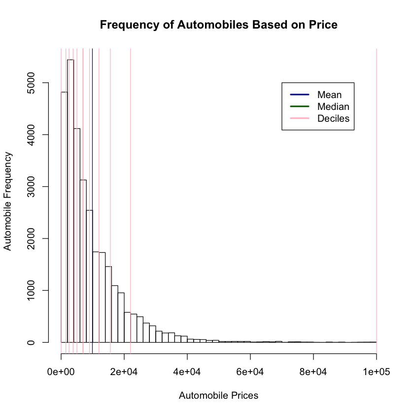

```r
price_frequency = subset(vposts$price, vposts$price > 10 & vposts$price<= 1e5)
mean_price_frequency = mean(price_frequency)
median_price_frequency = median(price_frequency)
dec_price_frequency = quantile(price_frequency, seq(0,1, by=.1), na.rm = TRUE)
hist(price_frequency, seq(0, 1e5, by=2000), main = "Frequency of Automobiles Based on Price", xlab = "Automobile Prices", ylab = "Automobile Frequency")
abline(v = mean_price_frequency, col = "Dark Blue")
abline(v = median_price_frequency, col = "Dark Green")
abline(v = dec_price_frequency, col = "Pink")
legend(7e4,5000, c("Mean", "Median", "Deciles"), lty=c(1,1,1), lwd=c(2.5,2.5,2.5), col=c("Dark Blue", "Dark Green", "Pink"))
label = c("mean","median")
value = c(mean_price_frequency,median_price_frequency)
rbind(label,value)
```

### Question 4: What are the different categories of vehicles, i.e. the type variable/column? What is the proportion for each category?

Different categories of vehicles

```r
levels(vposts$type)
```

1. 'bus'

2. 'convertible'

3. 'coupe'

4. 'hatchback'

5. 'mini-van'

6. 'offroad'

7. 'other'

8. 'pickup'

9. 'sedan'

10. 'SUV'

11. 'truck'

12. 'van'

13. 'wagon'

```
        bus convertible       coupe   hatchback    mini-van     offroad
     0.0012      0.0376      0.0866      0.0436      0.0241      0.0035
      other      pickup       sedan         SUV       truck         van
     0.0355      0.0484      0.3748      0.2242      0.0640      0.0270
      wagon
     0.0297
```

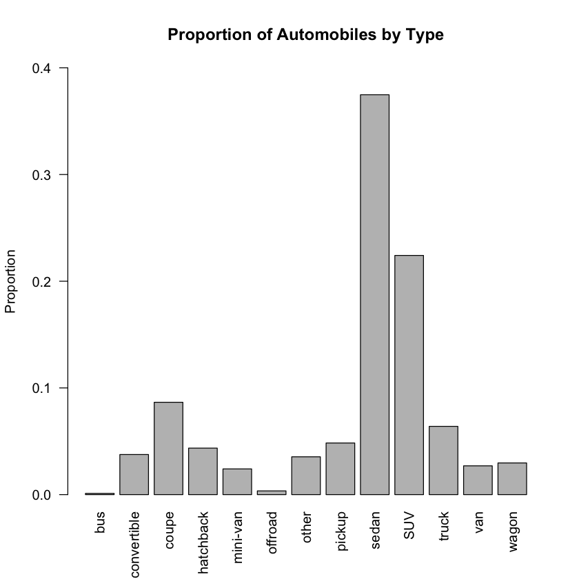

```r
car_type = table(vposts$type)
car_type_prob = car_type/sum(car_type, na.rm=TRUE)
round(car_type_prob, digits = 4)
barplot(car_type_prob, las=2, main="Proportion of Automobiles by Type", ylab = "Proportion", ylim=c(0,.40))
```

### Question 5: Display the relationship between fuel type and vehicle type. Does this depend on transmission type?

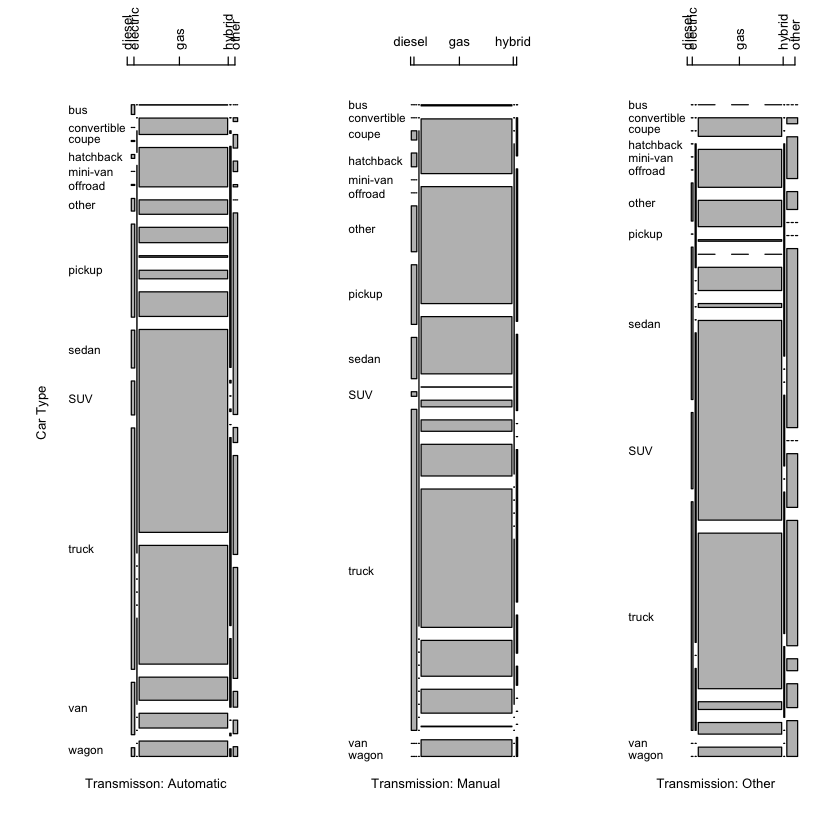

```r
splitted_trans = split(vposts, vposts$transmission)
Tables = lapply(splitted_trans, function(df) table(df$fuel, df$type))
par(mfrow = c(1,3))
types = dimnames(Tables$automatic)[[1]]
dimnames(Tables$automatic)[[1]] = rep(NA, length(types))
mosaicplot(Tables$automatic, las = 2, main = "", xlab ="Transmisson: Automatic", ylab = "Car Type", cex.axis = .9)
at = seq(0, 1, len = length(types))
axis(3, c(0.33, .37, .64, .93, .97), types, las = 2)

typesm = dimnames(Tables$manual)[[1]]
dimnames(Tables$manual)[[1]] = rep(NA, length(typesm))
mosaicplot(Tables$manual, las = 2, main = "", xlab ="Transmission: Manual", cex.axis = .9)
at = seq(0, 1, len = length(types))
axis(3, c(0.35, .37, .64, .96, .98), types)

typeso = dimnames(Tables$other)[[1]]
dimnames(Tables$other)[[1]] = rep(NA, length(typeso))
mosaicplot(Tables$other, las = 2, main = "", xlab ="Transmission: Other", cex.axis = .9)
at = seq(0, 1, len = length(typeso))
axis(3, c(0.33, .36, .64, .9, .97), types, las = 2)
```

There is an easily apparent difference within the area of the boxes depending on the transmission type. Vehicles that use other types of transmission use significantly more of the other type of gasoline than automatic or manual. On the other hand, manual is more evenly distributed between the various car types and gasoline types than the other two with the exception of trucks using significantly more diesel. Automatic and Other transmissions use more gasoline within SUV and Sedan types than manual.

### Question 6: How many different cities are represented in the dataset?

```r
levels(vposts$city)
```

1. 'boston'

2. 'chicago'

3. 'denver'

4. 'lasvegas'

5. 'nyc'

6. 'sac'

7. 'sfbay'

There are seven cities represented in the dataset.

### Question 7: Visually display how the number/proportion of "for sale by owner" and "for sale by dealer" varies across city?

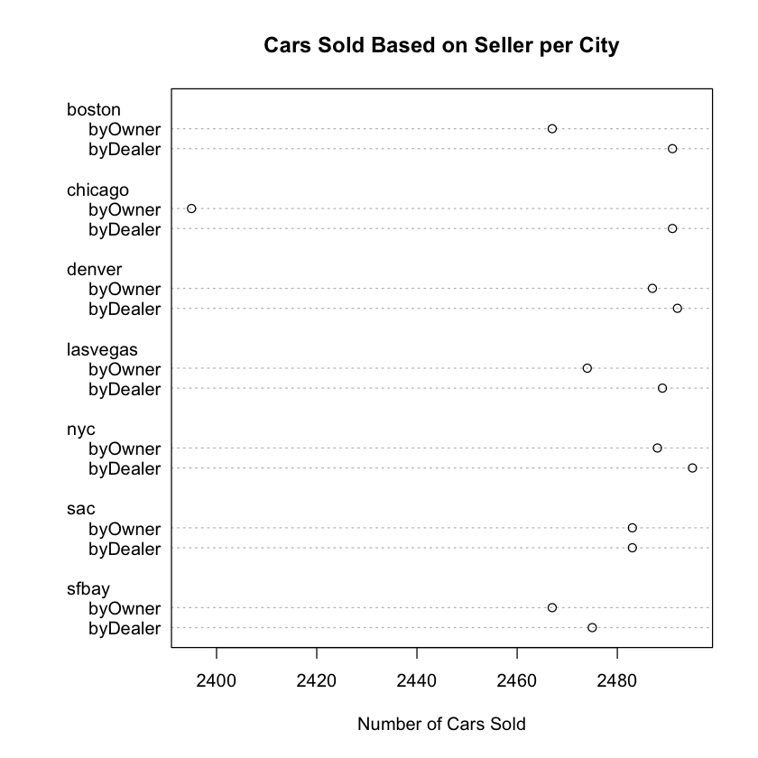

```r
par(mfrow=c(1,1))
Owner_upd = factor(c("byDealer", "byOwner") [vposts$byOwner + 1])
Owner_City= table(Owner_upd, vposts$city)
dotchart(Owner_City, main="Cars Sold Based on Seller per City", xlab="Number of Cars Sold")
```

### Question 8: What is the largest price for a vehicle in this data set? Examine this and fix the value. Now examine the new highest value for price.

```r
updvposts = vposts
Max_Price = which.max(updvposts$price)
updvposts[Max_Price, ]
updvposts$price[4741] = 18000
Max_Price = which.max(updvposts$price)
updvposts[Max_Price, ]
updvposts$price[4880] = 18000
```

|  | id | title | body | lat | long | posted | updated | drive | odometer | type | ⋯ | byOwner | city | time | description | location | url | price | year | maker | makerMethod |
| --- | --- | --- | --- | --- | --- | --- | --- | --- | --- | --- | --- | --- | --- | --- | --- | --- | --- | --- | --- | --- | --- |
| posted22491 | 5226036450 | Custom gto / 1968 and 1969 Pontiac GTO - $600030000 (Middleboro Massachusetts) | We have 1968 & 1969 Pontiac GTO's. Currently we are working on a 1968 end a 1969 Gto project is almost complete. Our Intention is the custom to specification by owner. Cost will be between $6000 & $30… | NA | NA | 2015-09-17 08:39:16 | 2015-09-21 17:59:33 | rwd | NA | sedan | ⋯ | TRUE | boston | 2015-09-21 21:04:00 | Custom gto / 1968 and 1969 Pontiac GTO | (Middleboro Massachusetts) | /sob/cto/5226036450.html | 600030000 | 1969 | pontiac | 1.5 |

|  | id | title | body | lat | long | posted | updated | drive | odometer | type | ⋯ | byOwner | city | time | description | location | url | price | year | maker | makerMethod |
| --- | --- | --- | --- | --- | --- | --- | --- | --- | --- | --- | --- | --- | --- | --- | --- | --- | --- | --- | --- | --- | --- |
| posted23881 | 5233041879 | Custom gto / 1968 and 1969 Pontiac GTO - $600030000 (Middleboro Massachusetts) | We have 1968 & 1969 Pontiac GTO's. Currently we are working on a 1968 end a 1969 Gto project is almost complete. Our Intention is the custom to specification by owner. Cost will be between $6000 & $30… | NA | NA | 2015-09-21 18:09:19 | NA | rwd | NA | sedan | ⋯ | TRUE | boston | 2015-09-21 21:09:00 | Custom gto / 1968 and 1969 Pontiac GTO | (Middleboro Massachusetts) | /sob/cto/5233041879.html | 600030000 | 1969 | pontiac | 1.5 |

The inputs are supposed to be between 6000 and 30,000 instead of the value of 600,030,000. Therefore, I split the outrageous number into the two bounds and then took the average of the two ends, replacing the old values with 18,000.

```r
Max_Price = which.max(updvposts$price)
updvposts[Max_Price, ]
updvposts$price[8140] = 2750
```

|  | id | title | body | lat | long | posted | updated | drive | odometer | type | ⋯ | byOwner | city | time | description | location | url | price | year | maker | makerMethod |
| --- | --- | --- | --- | --- | --- | --- | --- | --- | --- | --- | --- | --- | --- | --- | --- | --- | --- | --- | --- | --- | --- |
| posted6903 | 5233285975 | Seville SLS - $30002500 (6800 S California) | clean, fully loaded, nice shine, good running engine and trans, willing to trade for old school or truck?????????????????? Mounted on 22 inch rims new tires no bends no cracks | NA | NA | 2015-09-21 23:10:05 | 2015-09-22 07:53:25 | fwd | NA | sedan | ⋯ | TRUE | chicago | 2015-09-22 01:10:00 | Seville SLS | (6800 S California) pic | /chc/cto/5233285975.html | 30002500 | 2002 | cadillac | 3 |

The input is supposed to be between 3000 and 2500 instead of the combined 30,002,500. I split the outrageous number into the two bounds and then took the average of the two ends, replacing the old values with 2,750.

```r
Max_Price = which.max(updvposts$price)
updvposts[Max_Price, ]
updvposts$price[13937] = 20
```

|  | id | title | body | lat | long | posted | updated | drive | odometer | type | ⋯ | byOwner | city | time | description | location | url | price | year | maker | makerMethod |
| --- | --- | --- | --- | --- | --- | --- | --- | --- | --- | --- | --- | --- | --- | --- | --- | --- | --- | --- | --- | --- | --- |
| posted16005 | 5232610720 | NEW USED CAR, GOOD BAD CONDITION - $9999999 (EVERYWHERE) | Selling my car for some lunch money. $20 OBO. Comes with complimentary Oboe. | NA | NA | 2015-09-21 13:20:54 | NA | NA | NA | NA | ⋯ | TRUE | denver | 2015-09-21 14:20:00 | NEW USED CAR, GOOD BAD CONDITION | (EVERYWHERE) pic | /cto/5232610720.html | 9999999 | 2001 | honda | 1.5 |

The body column states the vehicle is being solf for 20 instead of 9999999.

```r
Max_Price = which.max(updvposts$price)
updvposts[Max_Price, ]
```

|  | id | title | body | lat | long | posted | updated | drive | odometer | type | ⋯ | byOwner | city | time | description | location | url | price | year | maker | makerMethod |
| --- | --- | --- | --- | --- | --- | --- | --- | --- | --- | --- | --- | --- | --- | --- | --- | --- | --- | --- | --- | --- | --- |
| posted21422 | 5229076274 | 2007 CHEVROLET MONTE CARLO LT - Easy Financing! Any Credit Auto Loans! BHPH! - $569500 (630-409-6888 - www.lot1autosales.com) | Stock ID: 10620Year: 2007Make: CHEVROLETModel: MONTE CARLOMiles: 139,567Price: $569,500Exterior Color: SILVERInterior Color: SILVEREngine: 6 CylindersTransmission: AutomaticVIN: 2G1WK15N479213363 Lot … | 41.91847 | -87.88354 | 2015-09-19 07:31:02 | NA | fwd | 139567 | NA | ⋯ | FALSE | chicago | 2015-09-19 09:30:00 | 2007 CHEVROLET MONTE CARLO LT - Easy Financing! Any Credit Auto Loans! BHPH! | (630-409-6888 - www.lot1autosales.com) pic map | /wcl/ctd/5229076274.html | 569500 | 2007 | chevrolet | 1.5 |

High yet reasonable price so stopped data cleaning individual points at this juncture. http://chicago.craigslist.org/wcl/ctd/5223662905.html

### Question 9: What are the three most common makes of cars in each city for "sale by owner" and for "sale by dealer"? Are they similar or quite different?

```r
by_owner = subset(vposts, vposts$byOwner == TRUE)
counts_owner = table(by_owner$city, by_owner$maker)
by_dealer = subset(vposts, vposts$byOwner == FALSE)
counts_dealer = table(by_dealer$city, by_dealer$maker)
```

Top 3 makes by owner

```r
top3_makes = function(city_counts) {
  top3_by_owner = order(city_counts, decreasing = TRUE)[1:3]
  colnames(counts_owner)[top3_by_owner]
}

apply(counts_owner, 1, top3_makes)
top3_makes = function(city_counts) {
  top3_by_dealer = order(city_counts, decreasing = TRUE)[1:3]
  colnames(counts_dealer)[top3_by_dealer]
}
```

| boston | chicago | denver | lasvegas | nyc | sac | sfbay |
| --- | --- | --- | --- | --- | --- | --- |
| ford | chevrolet | ford | ford | nissan | toyota | toyota |
| honda | ford | chevrolet | chevrolet | toyota | ford | honda |
| chevrolet | honda | toyota | toyota | honda | chevrolet | ford |

Top 3 makes by dealer

```r
apply(counts_dealer, 1, top3_makes)
```

| boston | chicago | denver | lasvegas | nyc | sac | sfbay |
| --- | --- | --- | --- | --- | --- | --- |
| ford | chevrolet | ford | ford | nissan | ford | toyota |
| toyota | ford | chevrolet | nissan | toyota | toyota | ford |
| chevrolet | nissan | dodge | chevrolet | honda | chevrolet | bmw |

### Question 10: Visually compare the distribution of the age of cars for different cities and for "sale by owner" and "sale by dealer". Provide an interpretation of the plots, i.e., what are the key conclusions and insights?

Cleaning the data

```r
sortedyear = sort(updyearvposts$Car_age, decreasing = TRUE)
head(sortedyear, 10)
subset(updyearvposts, updyearvposts$Car_age == 116)
```

[output not shown]

```r
updyearvposts = vposts
updyearvposts$Car_age = 2016-updyearvposts$year
Max_age = max(updyearvposts$Car_age, na.rm=TRUE)
updyearvposts[Max_age, ]
updyearvposts$year[8417] = 2004
```

|  | id | title | body | lat | long | posted | updated | drive | odometer | type | ⋯ | city | time | description | location | url | price | year | maker | makerMethod | Car_age |
| --- | --- | --- | --- | --- | --- | --- | --- | --- | --- | --- | --- | --- | --- | --- | --- | --- | --- | --- | --- | --- | --- |
| posted2011 | 5232768482 | 2006 Chevrolet Silverado 1500 W/Rear entertainment- YOUR APPROVED!! (guaranteed credit approved) | Looking for a car thats suits you at Afforable price and guaranteed approval,look no futher call Chris at 857 243 5844. At Cars4u we have the best interest rates in the market, our cars are priced und… | 42.728 | -71.181 | 2015-09-21 14:52:26 | NA | NA | NA | NA | ⋯ | boston | 2015-09-21 17:52:00 | 2006 Chevrolet Silverado 1500 W/Rear entertainment- YOUR APPROVED!! | (guaranteed credit approved) pic map | /nwb/ctd/5232768482.html | NA | 2006 | chevrolet | 1 | 10 |

```r
Min_age = min(updyearvposts$Car_age, na.rm=TRUE)
which.min(updyearvposts$Car_age)
updyearvposts[21975, ]
updyearvposts$year[21975] = 2002
updyearvposts$Car_age[21975] = 14
```

21975

|  | id | title | body | lat | long | posted | updated | drive | odometer | type | ⋯ | city | time | description | location | url | price | year | maker | makerMethod | Car_age |
| --- | --- | --- | --- | --- | --- | --- | --- | --- | --- | --- | --- | --- | --- | --- | --- | --- | --- | --- | --- | --- | --- |
| posted21888 | 5218261938 | Check Out This Spotless 2022 Honda Odyssey with 117,102 Miles - $6999 (Jamaica) | 2022 Honda Odyssey LX AT Automatic Gray Cloth on Silver Silver Pearl Metallic 104208 Take a look at this 2022 Honda Odyssey LX AT. It has only 117102 miles. Color: Silver Cloth on Silver Silver Pearl … | NA | NA | 2015-09-12 08:24:38 | 2015-09-12 08:24:40 | NA | 117102 | NA | ⋯ | nyc | 2015-09-12 11:24:00 | Check Out This Spotless 2022 Honda Odyssey with 117,102 Miles | (Jamaica) pic | /que/ctd/5218261938.html | 6999 | 2022 | honda | 1.5 | -6 |

```r
Car_age = 2016-updyearvposts$year
Min_age = min(Car_age, na.rm=TRUE)
which.min(Car_age)
updyearvposts[1929, ]
```

1929

|  | id | title | body | lat | long | posted | updated | drive | odometer | type | ⋯ | city | time | description | location | url | price | year | maker | makerMethod | Car_age |
| --- | --- | --- | --- | --- | --- | --- | --- | --- | --- | --- | --- | --- | --- | --- | --- | --- | --- | --- | --- | --- | --- |
| posted1928 | 5230473815 | 2016 Ford Fusion SE - $23744 (Haverhill, MA) | Autofair Ford of Haverhill address: 501 Broadway Haverhill MA, 01832phone: &phone; (978) 965-3673 ext 212text: Text 212 to (978) 965-3673 for more details link: http://12944.arrivesafeautos.com/p/2059… | 42.78457 | -71.11792 | 2015-09-20 07:11:09 | NA | fwd | 0 | NA | ⋯ | boston | 2015-09-20 10:11:00 | 2016 Ford Fusion SE | (Haverhill, MA) pic map | /nwb/ctd/5230473815.html | 23744 | 2016 | ford | 1.5 | 0 |

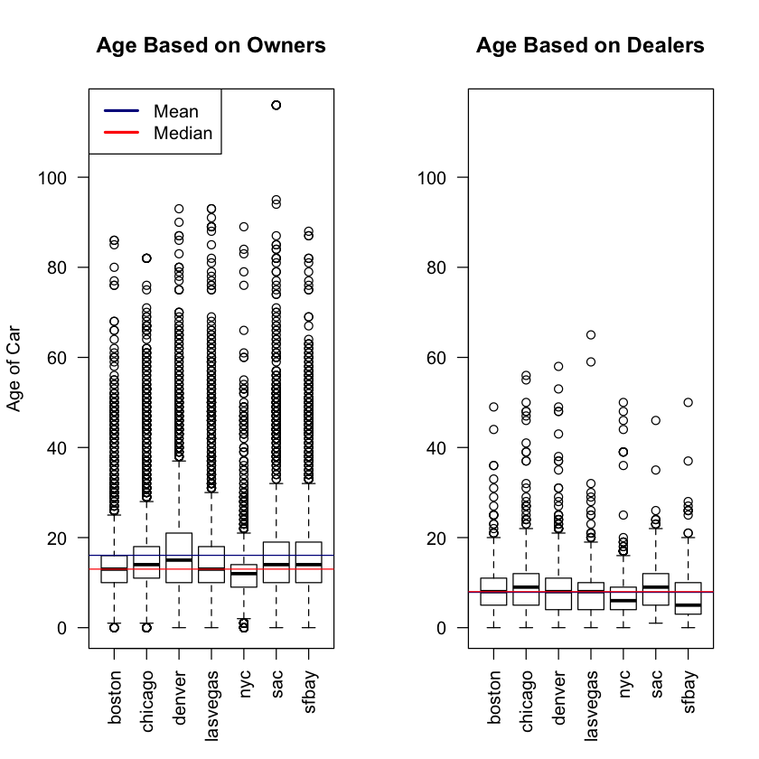

```r
by_owner_year = subset(updyearvposts, updyearvposts$byOwner == TRUE)
by_dealer_year = subset(updyearvposts, updyearvposts$byOwner == FALSE)
mean_owner_year = mean(by_owner_year$Car_age)
median_owner_year = median(by_owner_year$Car_age)
mean_dealer_year = mean(by_dealer_year$Car_age)
median_dealer_year = median(by_dealer_year$Car_age)
par(mfrow = c(1,2))
plot(by_owner_year$city, by_owner_year$Car_age, main = "Age Based on Owners", ylab = "Age of Car", ylim = c(0,115), las = 2)
abline(h = mean_owner_year, col = "Dark Blue")
abline(h = median_owner_year, col = "Red")
legend("topleft",100, c("Mean", "Median"), lty=c(1,1), lwd=c(2.5,2.5), col=c("Dark Blue", "Red"))
plot(by_dealer_year$city, by_dealer_year$Car_age, main = "Age Based on Dealers", ylim = c(0,115), las = 2)
abline(h = mean_dealer_year, col = "Dark Blue")
abline(h = median_dealer_year, col = "Red")
```

### Question 11: Plot the locations of the posts on a map? What do you notice?

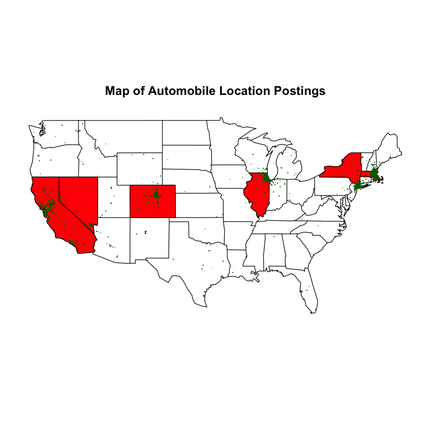

```r
library(maps)
par(mfrow = c(1,1))
map('state')
map('state', c("Massachusetts", "Illinois","Colorado", "Nevada", "New York","California"), add = TRUE, fill = TRUE, col = "red")
points(vposts$long, vposts$lat, col = "Dark green", pch=".", title ("Map of Automobile Location Postings"))
```

In the map the red states are the states in which the cities of interest are located. The green dots represent a single posting from that location. Looking at the map individuals posted cars in cities that were far away from their actual location. While most of the posting are centered around the city they were targeting, there were a significant amount that were in surrounding states and even non neighboring states. Therefore, this graph reveals that people lie about their location in order to increase the chances of selling their car.

### Question 12: Summarize the distribution of fuel type, drive, transmission, and vehicle type. Find a good way to display this information.

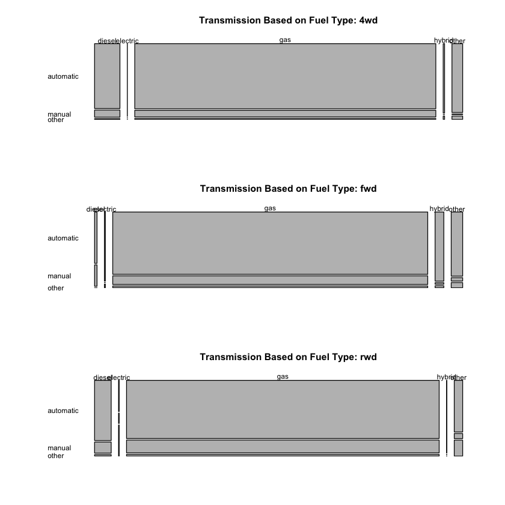

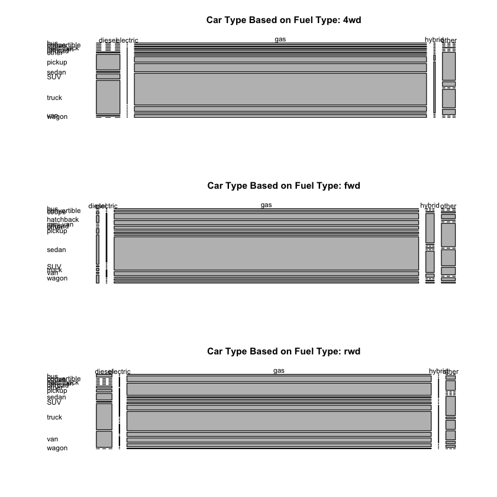

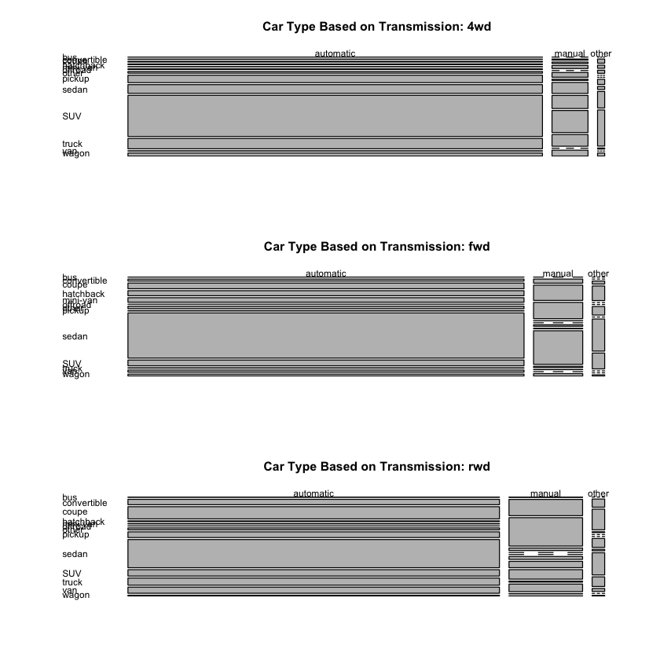

```r
par(mfrow = c(3,1))
splitted_bydrive = split(vposts, updyearvposts$drive)
Table_bydrive_fuel_transmission = lapply(splitted_bydrive, function(df) table(df$fuel, df$transmission))
mosaicplot(Table_bydrive_fuel_transmission$`4wd`, las = 1, main= "                    Transmission Based on Fuel Type: 4wd", cex.axis = .9)
mosaicplot(Table_bydrive_fuel_transmission$fwd, las = 1, main= "                    Transmission Based on Fuel Type: fwd", cex.axis = .9)
mosaicplot(Table_bydrive_fuel_transmission$rwd, las = 1, main= "                    Transmission Based on Fuel Type: rwd", cex.axis = .9)
Table_bydrive_fuel_type = lapply(splitted_bydrive, function(df) table(df$fuel, df$type))
mosaicplot(Table_bydrive_fuel_type$`4wd`, las = 1, main= "                    Car Type Based on Fuel Type: 4wd", cex = .9)
mosaicplot(Table_bydrive_fuel_type$fwd, las = 1, main= "                    Car Type Based on Fuel Type: fwd", cex = .9)
mosaicplot(Table_bydrive_fuel_type$rwd, las = 1, main= "                    Car Type Based on Fuel Type: rwd", cex = .9)
Table_bydrive_transmission_type = lapply(splitted_bydrive, function(df) table(df$transmission, df$type))
mosaicplot(Table_bydrive_transmission_type$`4wd`, las = 1, main= "                    Car Type Based on Transmission: 4wd", cex.axis = .9)
mosaicplot(Table_bydrive_transmission_type$fwd, las = 1, main= "                    Car Type Based on Transmission: fwd", cex.axis = .9)
mosaicplot(Table_bydrive_transmission_type$rwd, las = 1, main= "                    Car Type Based on Transmission: rwd", cex.axis = .9)
```

Examining the above graph 4wd and rwd are relatively similar based on fuel type. Both these types of fuel follow a similar distribution with only slight variations that can be attributed to chance seen in gas and diesel. These types of drive are significantly different than fwd, seen in the lack of diesel cars with fwd compared to rwd and 4wd, as well as fwd, having more gas and hybrid cars. Rwd is also significantly different than fwd and 4wd within electric cars. Transmission type has a slight deviation between the fuel distributions, however this difference is minimal and can be attributed to random chance, except for the biggest deviation between 4wd and fwd in which there appears to be a slight significance. Fuel type is heavily affected by transmission where a majority of cars drive automatic, across all transmission types and gas is the main source of fuel, which makes sense since automatic cars and gas fueled cars are the most prevalent cars in the world.

### Question 13: Plot odometer reading and age of car? Is there a relationship? Similarly, plot odometer reading and price? Interpret the result(s). Are price and age of car related?

```r
Max_odometer = max(updyearvposts$odometer, na.rm=TRUE)
which.max(updyearvposts$odometer)
updyearvposts[18161, ]
```

18161

|  | id | title | body | lat | long | posted | updated | drive | odometer | type | ⋯ | city | time | description | location | url | price | year | maker | makerMethod | Car_age |
| --- | --- | --- | --- | --- | --- | --- | --- | --- | --- | --- | --- | --- | --- | --- | --- | --- | --- | --- | --- | --- | --- |
| posted8487 | 5223826379 | 2006 hyundai tiburon - $3000 (north las vegas) | i have 2006 hyundai tiburon in good conditions black leather interior and white outside runs and drives its beautifull and ac works clean title and its a 2006 my loss ur gain call me if intrested ask … | NA | NA | 2015-09-15 18:43:12 | 2015-09-21 21:32:24 | fwd | 1234567890 | sedan | ⋯ | lasvegas | 2015-09-21 13:59:00 | 2006 hyundai tiburon | (north las vegas) pic | /cto/5223826379.html | 3000 | 2006 | hyundai | 1 | 10 |

#### Odometer mileage based on the age of car.

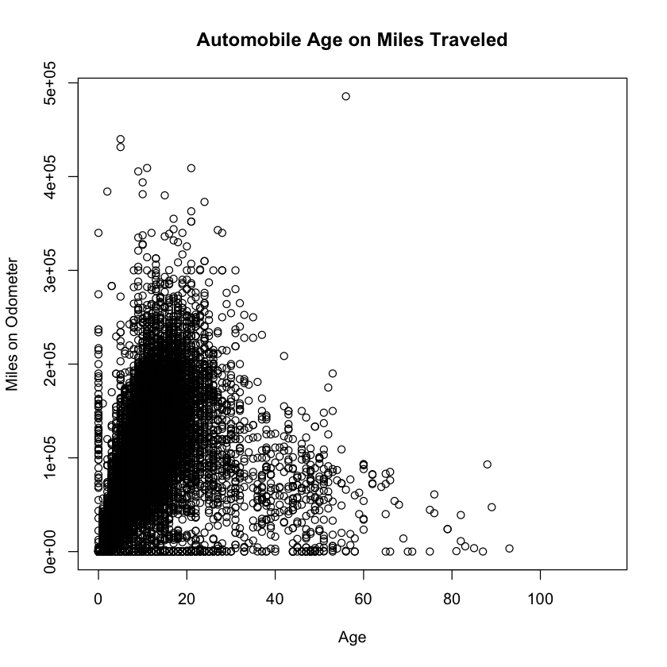

```r
Fix_odometer_vposts = subset(updyearvposts, updyearvposts$odometer <= 5e5)
plot(Fix_odometer_vposts$Car_age, Fix_odometer_vposts$odometer, main = "Automobile Age on Miles Traveled", xlab = "Age", ylab = "Miles on Odometer", xlim = c(0,115))
```

#### Odometer mileage based on price of the vehicle.

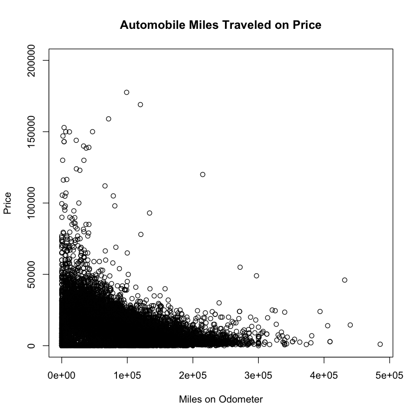

```r
plot(Fix_odometer_vposts$odometer, Fix_odometer_vposts$price, main = "Automobile Miles Traveled on Price", xlab = "Miles on Odometer", ylab = "Price", ylim = c(0,2e5))
```

Cutting out outliers significantly outside the normal pricing range there is negative correlation between miles and price. Most likely because less miles usually means a newer car that has more potential life.

#### Price and Age of Car

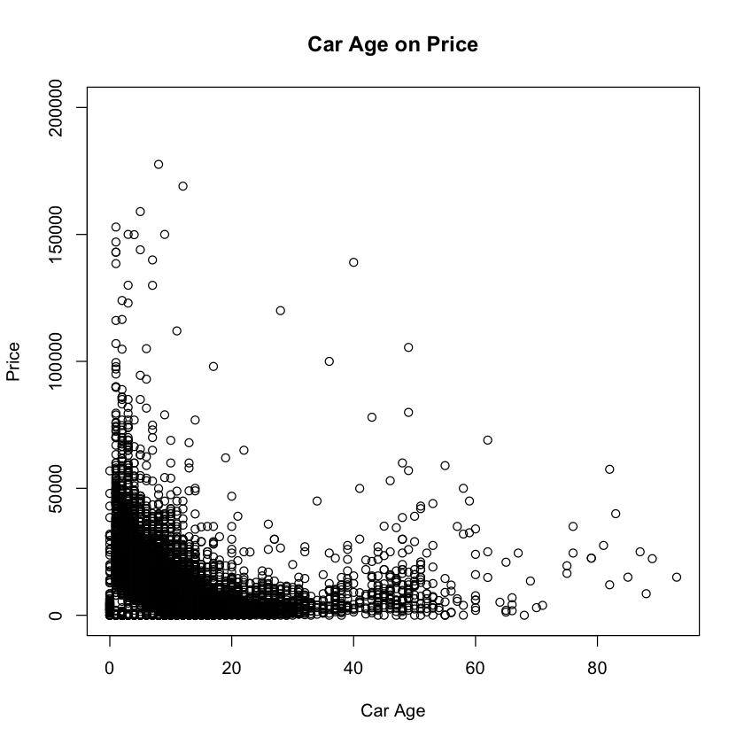

```r
plot(Fix_odometer_vposts$Car_age, Fix_odometer_vposts$price, main = "Car Age on Price", xlab = "Car Age", ylab = "Price", ylim = c(0,2e5))
```

### Question 14: Identify the "old" cars. What manufacturers made these? What is the price distribution for these?

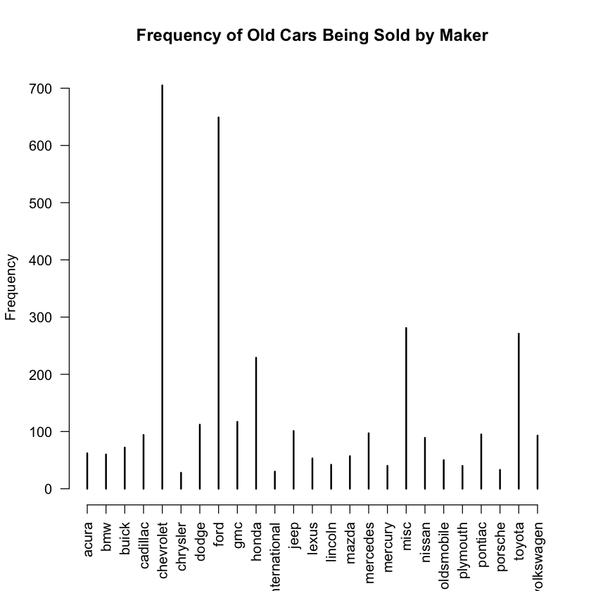

```r
oldcars = subset(updyearvposts, updyearvposts$Car_age >= 20)
sort_oldcars_newMaker = head(sort(table(oldcars$newMaker), decreasing = TRUE), 30)
tt = table(oldcars$maker)
to_remove = names(tt[tt < 25])
oldcars$newMaker = oldcars$maker
oldcars$newMaker[oldcars$newMaker %in% to_remove] = "misc"
plot(table(oldcars$newMaker), las = 2, main = "Frequency of Old Cars Being Sold by Maker", ylab = "Frequency")
```

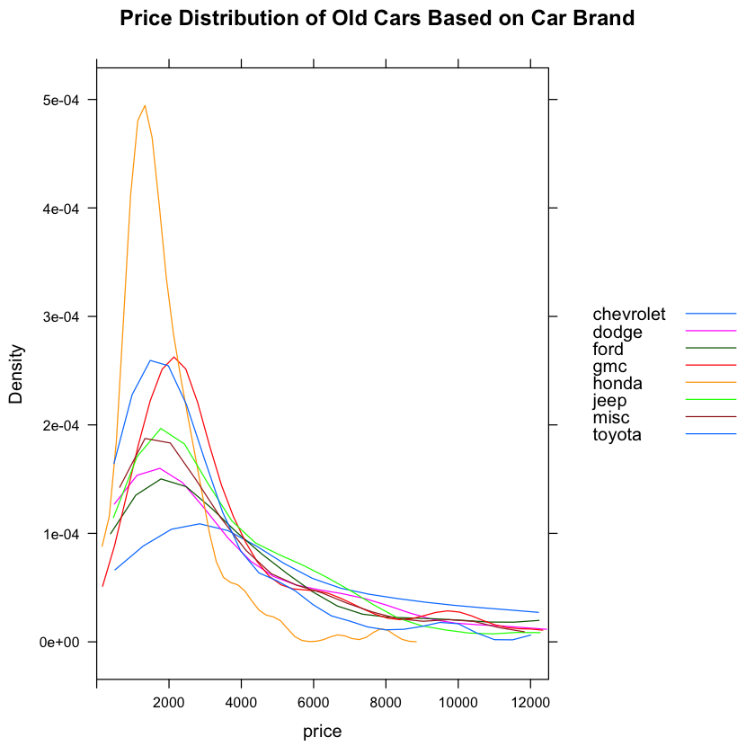

```r
library(lattice)
ttt = table(oldcars$maker)
to_remove = names(ttt[ttt < 100])
oldcars$newMaker_price = oldcars$maker
oldcars$newMaker_price[oldcars$newMaker_price %in% to_remove] = "misc"
oldcars_updprice = subset(oldcars, oldcars$price < 3e4)
sort_oldcars_newMaker_price = head(sort(table(oldcars$newMaker_price), decreasing = TRUE), 20)
densityplot(~ price, oldcars_updprice, group = newMaker_price, plot.points = FALSE,  auto.key = list(space = "right"), main="Price Distribution of Old Cars Based on Car Brand", xlim=c(0,1.25e4))
```

### Question 15: I have omitted one important variable in this data set. What do you think it is? Can we derive this from the other variables? If so, sketch possible ideas as to how we would compute this variable.

Looking at the categories for vposts a major variable that is missing is MPG. MPG is a big factor for buyers since gas is a variable cost depending on the car. In order to derive this variable, you would have to look at the body column and search for MPG. Choose either MPG for city, highway or both (most likely by highway since that is standard). Then once MPG is found copy the numeric value and insert this number into a new column labeled MPG.

### Question 16: Display how condition and odometer are related. Also how condition and price are related. And condition and age of the car. Provide a brief interpretation of what you find.

#### Cleaning the data

```r
updated_condition = vposts$condition
condition_table = table(updated_condition)
sort(condition_table, decreasing = TRUE, 20)
Fix_odometer_vposts = subset(updyearvposts, updyearvposts$odometer <= 5e5)
important_conditions = ordered(as.character(Fix_odometer_vposts$condition),  levels = c("new", "like new", "excellent", "good", "fair", "used", "salvage"))
table(important_conditions)
```

```
updated_condition
                       excellent                             good
                            7543                             4663
                        like new                             used
                            2898                             1180
                            fair                              new
                             776                              273
                         salvage                        certified
                              61                               54
                        preowned                        very good
                              10                               10
                           parts                   needs bodywork
                               5                                3
                         project               carfax guarantee!!
                               3                                2
                  needs restored                        pre owned
                               2                                2
                 superb original                            0used
                               2                                1
                         207,400                        ac/heater
                               1                                1
complete parts car, blown engine                front side damage
                               1                                1
           hit and run :( gently                           honnda
                               1                                1
                            mint               muscle car restore
                               1                                1
              needs restoration!              needs total restore
                               1                                1
                      needs work             needs work/for parts
                               1                                1
                            nice         nice rolling restoration
                               1                                1
                      nice teuck                      not running
                               1                                1
                       pre-owned                         preownes
                               1                                1
                     project car              rebuildable project
                               1                                1
                     restoration              restoration project
                               1                                1
                         restore                         restored
                               1                                1
                  rough but runs
                               1
```

```
important_conditions
      new  like new excellent      good      fair      used   salvage
      155      2301      6088      3665       545      1180        45
```

#### Condition on Odometer

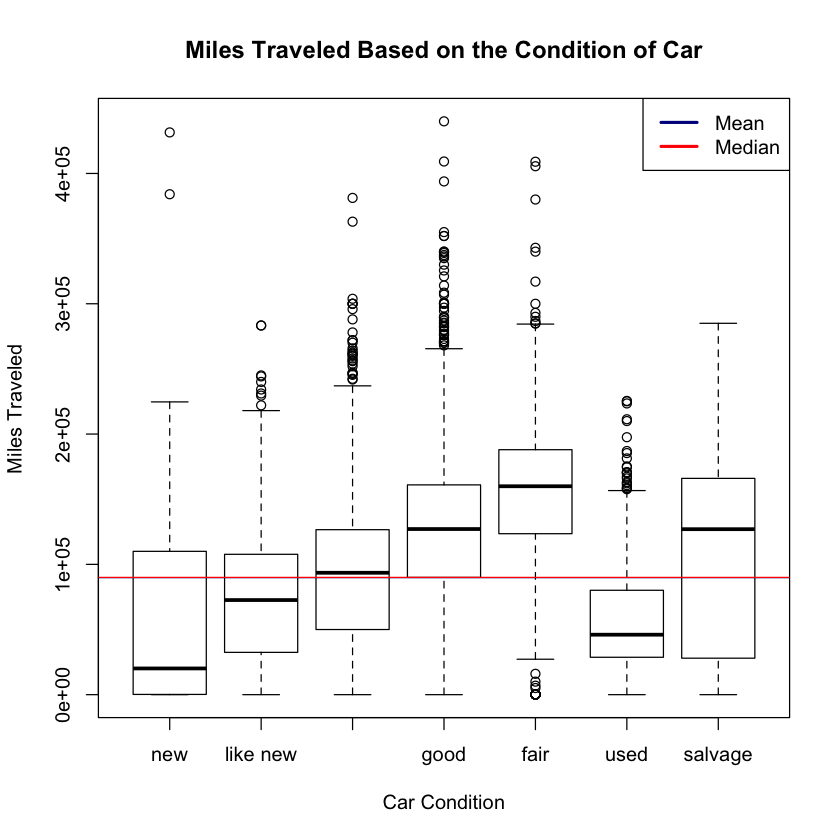

```r
plot(important_conditions, Fix_odometer_vposts$odometer, main = "Miles Traveled Based on the Condition of Car", xlab = "Car Condition", ylab = "Miles Traveled")
mean_odometer_condition = mean(Fix_odometer_vposts$odometer)
median_odometer_condition = median(Fix_odometer_vposts$odometer)
abline(h = mean_odometer_condition, col = "Dark Blue")
abline(h = median_odometer_condition, col = "Red")
legend("topright",100, c("Mean", "Median"), lty=c(1,1), lwd=c(2.5,2.5), col=c("Dark Blue", "Red"))
```

Based on the box and whisker plot above the better the condition of a car the fewer miles traveled. This makes sense since the more you travel with a car the more used it becomes. This trend continues as a car becomes worse quality except for used and salvage. The option used is not descriptive and therefore people could have selected used for their cars even if they had minimal use. Salvage, on the other hand, usually happens when a car becomes totaled or too expensive to fix. Totaled cars can happen at any time during the lifespan of a car due to the unpredictability of accidents, seen in the wide range of data points within the salvage column.

#### Condition on Price

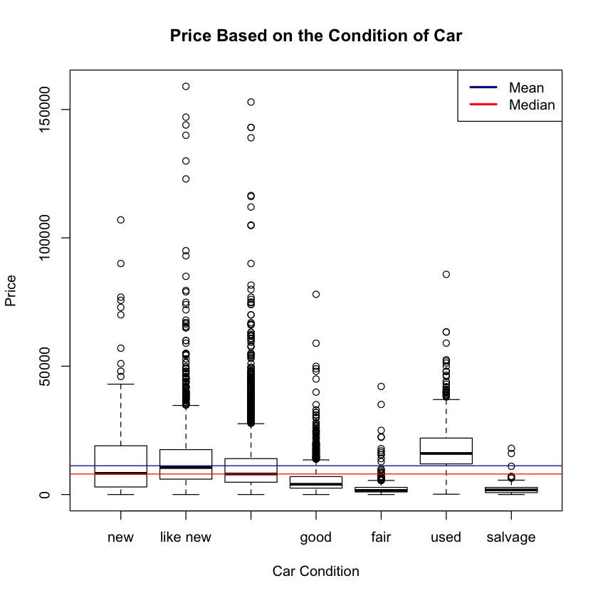

```r
Fix_odometer_vposts_price = subset(Fix_odometer_vposts, Fix_odometer_vposts$price <= 2e5)
important_conditions_price = ordered(as.character(Fix_odometer_vposts_price$condition),  levels = c("new", "like new", "excellent", "good", "fair", "used", "salvage"))
plot(important_conditions_price, Fix_odometer_vposts_price$price, main = "Price Based on the Condition of Car", xlab = "Car Condition", ylab = "Price")
mean_price_condition = mean(Fix_odometer_vposts_price$price)
median_price_condition = median(Fix_odometer_vposts_price$price)
abline(h = mean_price_condition, col = "Dark Blue")
abline(h = median_price_condition, col = "Red")
legend("topright",100, c("Mean", "Median"), lty=c(1,1), lwd=c(2.5,2.5), col=c("Dark Blue", "Red"))
```

Price follows a similar distribution to miles traveled, which is a result of the linear relationship between these two factors. The main difference is seen in the new column where new cars are actually lower in price than cars tagged as like new. This is most likely due to the fact that new and like new cars can be seen as similar options, meaning that these two options could be grouped together. As the condition of a car decreases so does the price, besides used cars, which presents a statistical anomaly. As mentioned in the previous graph, the used option is ambiguous and so people could have driven their car once and then put it for sale as used.

#### Condition on Age

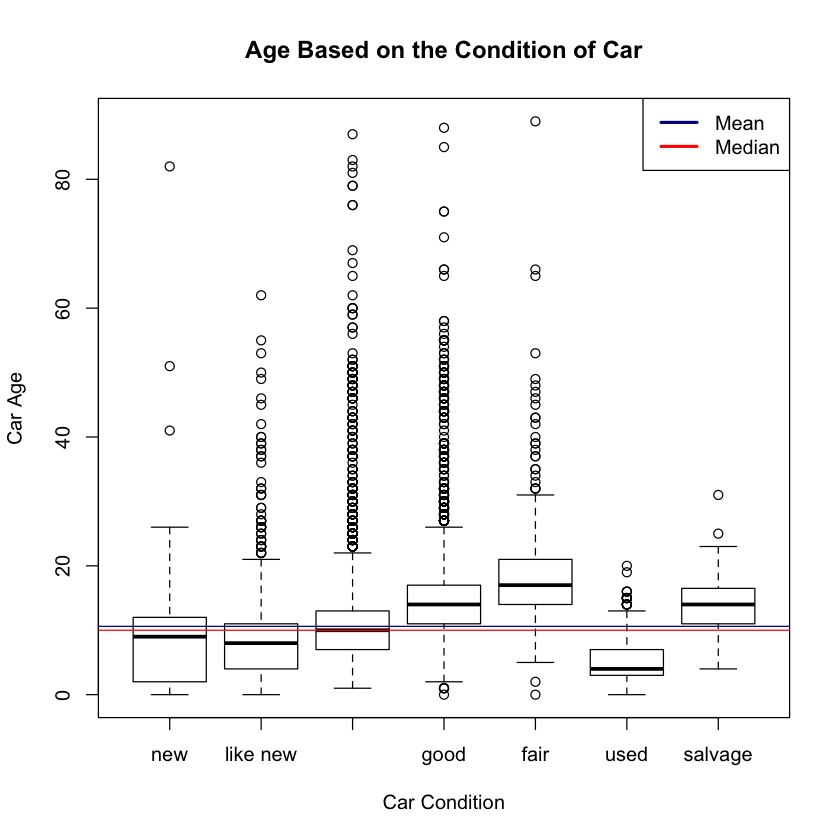

```r
plot(important_conditions_price, Fix_odometer_vposts_price$Car_age, main = "Age Based on the Condition of Car", xlab = "Car Condition", ylab = "Car Age")
mean_age_condition = mean(Fix_odometer_vposts_price$Car_age)
median_age_condition = median(Fix_odometer_vposts_price$Car_age)
abline(h = mean_age_condition, col = "Dark Blue")
abline(h = median_age_condition, col = "Red")
legend("topright",100, c("Mean", "Median"), lty=c(1,1), lwd=c(2.5,2.5), col=c("Dark Blue", "Red"))
```

Appendix:

1. [Chicago Craigslist](http://chicago.craigslist.org/wcl/ctd/5223662905.html)
2. Piazza
3. Office Hours
   1. Professor Duncan Temple Lang
   2. Nicholas Ulle
4. Stackoverflow
5. [cran.r-project.org](https://cran.r-project.org/)
6. http://www.statmethods.net/
7. http://stat.ethz.ch/R-manual/

Worked with:

1. Hannah Kosinovsky
2. Sierra Tevlin
3. Chad Pickering
4. Rico Lin